# NBA Game Predictions

# Initial setup

```r
game_data <- read_csv("NBA Game Data 20162017.csv")
game_data <- game_data %>%
                select(date = Date, away_team = "Visitor/Neutral", home_team = "Home/Neutral", pts_away = PTS_A, pts_home = PTS_H, overtime = OT) %>%
                mutate(overtime = ifelse (is.na(overtime), 0L,
                                          ifelse(stringr::str_length(overtime) == 2, 1L, as.integer(substring(overtime, 1, 1)))),
                       score_diff = ifelse(overtime == 0, pts_away - pts_home, 0L))
```

```
NAs introduced by coercion
```

```r
# create a single identifier used for both away and home teams
unique_teams <- sort(unique(c(game_data$away_team, game_data$home_team)))
team_mapping_table <- tibble(team_name = unique_teams, team_id = 1:length(unique_teams))
lookup_team_id <- function(team_name_lookup, mapping_table) {
  tmp_table <- filter(mapping_table, team_name == team_name_lookup)
  if (nrow(tmp_table) != 1) {
    stop(paste("lookup-rows should be equal to one but found", nrow(tmp_table), "instead"))
  }
  out <- tmp_table$team_id
  out
}
team_id <- map_int(c(game_data$away_team, game_data$home_team), lookup_team_id, mapping_table = team_mapping_table)
N_games <- nrow(game_data)
N_teams = length(team_mapping_table$team_id)
game_data <- game_data %>% mutate(away_team_id = team_id[1:N_games], home_team_id = team_id[(N_games + 1):(2 * N_games)])
N_games_per_team <- 82
n_sims <- 4000
```

```r
paste("Average score difference:", round(mean(game_data$score_diff), 2))
```

```
[1] "Average score difference: -3.07"
```

```r
paste("Standard deviation of score difference:", round(sd(game_data$score_diff), 2))
```

```
[1] "Standard deviation of score difference: 13.64"
```

```r
paste("Number of overtime games:", round(sum(game_data$score_diff == 0), 2))
```

```
[1] "Number of overtime games: 70"
```

```r
paste("Average points scored by away team:", round(mean(game_data$pts_away), 2))
```

```
[1] "Average points scored by away team: 104.02"
```

```r
paste("Variance of away points:", round(var(game_data$pts_away), 2))
```

```
[1] "Variance of away points: 148.61"
```

```r
paste("Average points scored by home team:", round(mean(game_data$pts_home), 2))
```

```
[1] "Average points scored by home team: 107.17"
```

```r
paste("Variance of home points:", round(var(game_data$pts_home), 2))
```

```
[1] "Variance of home points: 141.74"
```

```r
summary(game_data)
```

```
     date            away_team          home_team            pts_away      pts_home        overtime         score_diff       away_team_id   home_team_id
 Length:1230        Length:1230        Length:1230        Min.   : 68   Min.   : 64.0   Min.   :0.00000   Min.   :-49.000   Min.   : 1.0   Min.   : 1.0
 Class :character   Class :character   Class :character   1st Qu.: 96   1st Qu.: 99.0   1st Qu.:0.00000   1st Qu.:-12.000   1st Qu.: 8.0   1st Qu.: 8.0
 Mode  :character   Mode  :character   Mode  :character   Median :104   Median :107.0   Median :0.00000   Median : -3.000   Median :15.5   Median :15.5
                                                          Mean   :104   Mean   :107.2   Mean   :0.06504   Mean   : -3.074   Mean   :15.5   Mean   :15.5
                                                          3rd Qu.:112   3rd Qu.:115.0   3rd Qu.:0.00000   3rd Qu.:  6.000   3rd Qu.:23.0   3rd Qu.:23.0
                                                          Max.   :143   Max.   :149.0   Max.   :4.00000   Max.   : 37.000   Max.   :30.0   Max.   :30.0
```

Here we see both the home and away points scored are a bit over-dispersed.

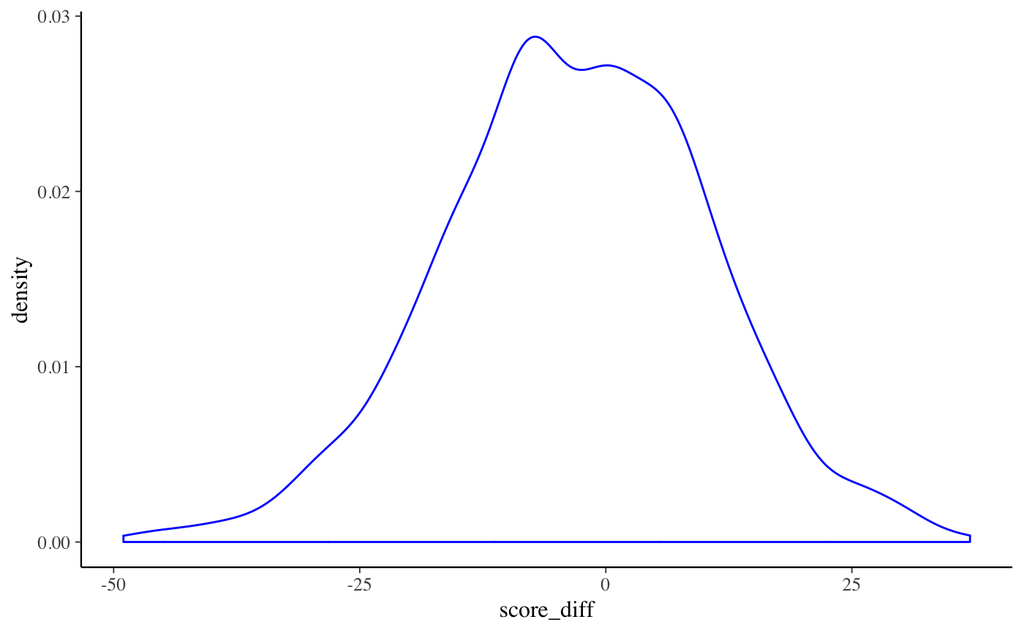

```r
ggplot(data = game_data, mapping = aes(x = score_diff)) + geom_density(color = "blue")
```

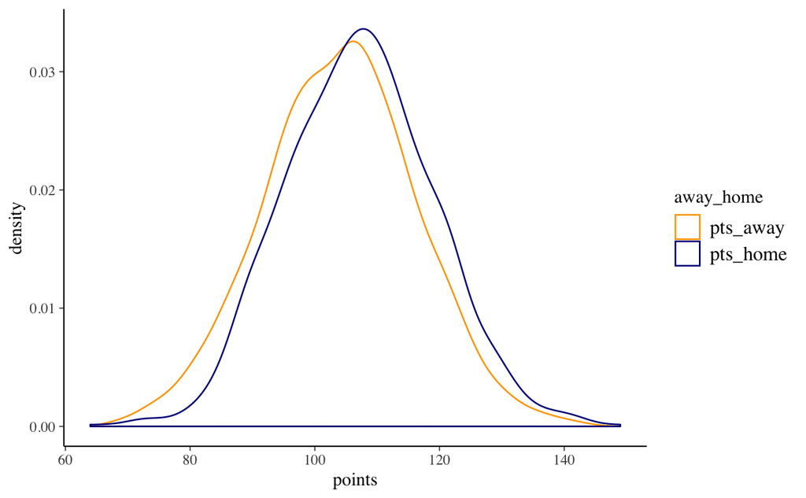

```r
game_data %>%
  gather(key = "away_home", value = "points", pts_away, pts_home) %>%
  ggplot(aes(x = points, col = away_home)) + geom_density() + scale_color_manual(values = c("orange", "darkblue"))
```

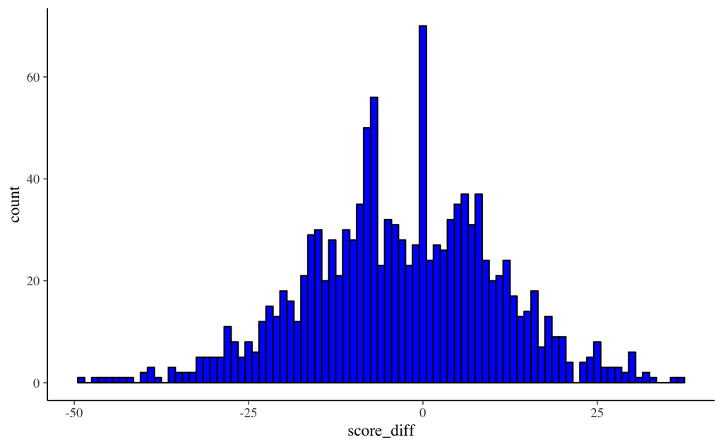

```r
ggplot(data = game_data, mapping = aes(x = score_diff)) + geom_histogram(binwidth = 1, fill = "blue", color = "black")
```

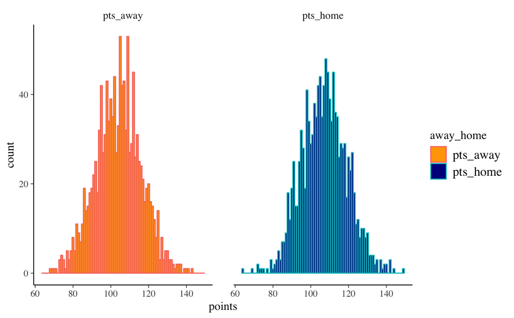

```r
game_data %>%
  gather(key = "away_home", value = "points", pts_away, pts_home) %>%
  ggplot(aes(x = points, col = away_home, fill = away_home)) + geom_histogram(binwidth = 1) + scale_fill_manual(values = c("orange", "darkblue")) + facet_wrap("away_home")
```

It appears the observed score difference seems to be bimodal, and there appears to be some home-court advantage (more negative score differences than positive). We will use this in the model later. Also, the distribution of points scored seems relatively bell-shaped, with perhaps a bit more mass towards the tails than we would expect from a normal distribution. Finally, the distribution shows that overtime games are more frequent than might be expected by pure chance.

```r
stan_data <- list(
                    N_games = N_games,
                    N_teams = N_teams,
                    away_points = game_data$pts_away,
                    home_points = game_data$pts_home,
                    overtime = game_data$overtime,
                    away_team_id = game_data$away_team_id,
                    home_team_id = game_data$home_team_id
                  )
```